# To what extent can student academic performance be predicted based on family-related factors?

Author

Iden McElhone

```python
# Imports
import pandas as pd
import seaborn.objects as so
import matplotlib.pyplot as plt
import sklearn
```

## Introduction

This project investigates the extent to which **student academic performance can be predicted based on family-related factors**, through **correlation analysis** and **machine learning**. The study explores the *Student Performance* dataset from the University of Carolina’s Machine Learning Repository (Cortez 2008), which contains familial and academic attributes of students from two Portuguese schools.

## Preprocessing

Before performing clustering and classification tasks, student data from Mathematics and Portuguese courses were **merged**, and selected family-related features were retained. Final grades were then **normalized and grouped** into a categorical variable, `"grades_grouped"`, which classifies grades into `"Low"`, `"Medium"` and `"High"`.

```python
# Relevant columns and maximum grade possible
COLS = ["Pstatus", "Medu", "Fedu", "Mjob", "Fjob", "famrel", "G3"]
MAX_GRADE = 20

def preprocess_data(df):
    """
    Takes a dataframe, renames and standardises the grade column, and returns a new dataframe with
    the grades grouped into low, medium and high classes.
    """
    # Standardise final grades to a 0-1 scale
    df['G3'] = df['G3'] / MAX_GRADE

    # Rename the grade column
    df.rename(columns={"G3": "grade"}, inplace=True)

    # Group grades into low, medium and high
    df['grades_grouped'] = pd.qcut(df['grade'], q=3, labels=["Low", "Medium", "High"])

    return df
```

```python
# Read CSV files into dataframes
math_df = pd.read_csv("./data/student-mat.csv", sep=";", usecols=COLS)
por_df = pd.read_csv("./data/student-por.csv", sep=";", usecols=COLS)

# Merge the dataframes vertically
df = pd.concat([math_df, por_df], axis=0)

df = preprocess_data(df)
df
```

Table 1: Merged Student Performance DataFrame

|  | Pstatus | Medu | Fedu | Mjob | Fjob | famrel | grade | grades_grouped |
| --- | --- | --- | --- | --- | --- | --- | --- | --- |
| 0 | A | 4 | 4 | at_home | teacher | 4 | 0.30 | Low |
| 1 | T | 1 | 1 | at_home | other | 5 | 0.30 | Low |
| 2 | T | 1 | 1 | at_home | other | 4 | 0.50 | Low |
| 3 | T | 4 | 2 | health | services | 3 | 0.75 | High |
| 4 | T | 3 | 3 | other | other | 4 | 0.50 | Low |
| ... | ... | ... | ... | ... | ... | ... | ... | ... |
| 644 | T | 2 | 3 | services | other | 5 | 0.50 | Low |
| 645 | T | 3 | 1 | teacher | services | 4 | 0.80 | High |
| 646 | T | 1 | 1 | other | other | 1 | 0.45 | Low |
| 647 | T | 3 | 1 | services | services | 2 | 0.50 | Low |
| 648 | T | 3 | 2 | services | other | 4 | 0.55 | Medium |

1044 rows × 8 columns

### Dataset Overview

Each column also has specific meanings and value types, this is provided in the text file of the dataset (Cortez 2008):

- **`Pstatus`**: Parental cohabitation status
  - `'T'` – living together
  - `'A'` – apart
- **`Medu`** and **`Fedu`**: Parental education level
  - `0` – no education
  - `1` – primary education (4th grade)
  - `2` – 5th to 9th grade
  - `3` – secondary education
  - `4` – higher education
- **`Mjob`** and **`Fjob`**: Parent’s jobs
  - `'teacher'` – teacher
  - `'health'` – health care related
  - `'services'` – civil services (e.g. administrative or police)
  - `'at home` – no job
  - `'other'` – other jobs
- **`famrel`**: Quality of family relationships (as rated by the student)
  - `1` – very bad
  - `2` – bad
  - `3` – average
  - `4` – good
  - `5` – excellent
- **`G3`** now renamed to **`grade`**: Grade of student out of 20, now normalised between 0 and 1.

## Correlation Analysis

Correlation analysis serves as an insight to **feature selection** and interpretation for the machine learning models used later in the project. By identifying which variables show stronger associations with student performance, we can estimate their potential **predictive power**.

To examine the relationships between family-related factors and student academic performance,  
**Normalised Mutual Information (NMI)** is used as a correlation measure (Kvalseth 2017).

NMI is well-suited for analysing associations between categorical data without assuming any specific relationship, unlike **Pearson’s correlation coefficient**, which is designed for continuous variables and assumes linear relationships (Schober, Boer, and Schwarte 2018). As noted by Steuer et al. (2002) , mutual information provides a more general criterion over Pearson’s correlation for investigating variable relationships.

NMI measures the amount of information that one variable provides about another, with values ranging from:  
- `0` (no mutual information)  
- `1` (perfect dependence)

This approach is most appropriate for our analysis because:  
- All features are **categorical** (Kvalseth 2017).  
- The grades have been grouped into three ordinal categories: `"Low"`, `"Medium"`, and `"High"`.

```python
# Defining the target variable and features
target_var = df["grades_grouped"]
features = ["Pstatus", "famrel", "Medu", "Fedu", "Mjob", "Fjob"]

def compute_nmi_scores(df, features, target_var):
    """
    Takes a dataframe, and computes the NMI score between each feature and the target variable provided,
    returns a dictionary of the features as the key, and the NMI score as the value.
    """
    nmi_scores = {}

    # Computing the NMI score for each feature
    for feature in features:
        nmi = sklearn.metrics.normalized_mutual_info_score(target_var, df[feature], average_method = "min")
        nmi_scores[feature] = nmi

    return nmi_scores


def plot_nmi_scores(nmi_scores):
    """
    Takes a dictoinary of features and their corresponding NMI score, and plots a bar chart with
    the features on the x-axis and the NMI scores on the y-axis.
    """
    # Convert NMI scores dictionary to a DataFrame
    data = pd.DataFrame({
        "Feature": list(nmi_scores.keys()),
        "NMI Score": list(nmi_scores.values())
    })

    # Create bar plot
    plot = (
        so.Plot(data, x="Feature", y="NMI Score")
        .add(so.Bar())
        .label(
            title="NMI Scores of Family Related Features vs Student Grade",
            x="Features",
            y="NMI Score"
        )
    )

    return plot
```

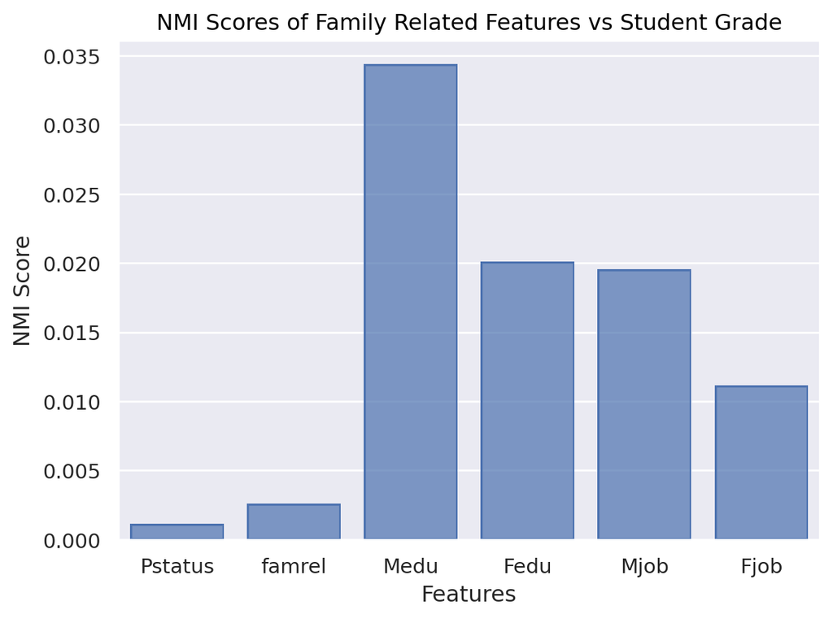

Figure 1: NMI Scores of Family related attributes against Student Grade

```python
nmi_scores = compute_nmi_scores(df, features, target_var)
nmi_plot = plot_nmi_scores(nmi_scores)
nmi_plot
```

The bar chart (Figure 1) reveals that all the NMI scores are relatively low, suggesting weak associations between these family related factors and student academic performance.

The quality of family relationships shows (`famrel`) a low NMI score of **0.002**, indicating a weak association with student performance. Parental cohabitation status (`Pstatus`) displays the weakest relationship, with an NMI score of just **0.001**.

This suggests that parental education and employment characteristics, particularly maternal education and job, have a more significant impact on child academic outcomes as compared to the family relationship quality and the parental cohabitation status. Mother’s job type shows a notably stronger association than father’s job type, which mirrors the pattern observed with parental education levels, possibly because mothers may be more directly involved in children’s academic support. While the relationships with **family dynamics** are minimal, they are not entirely absent as they still have small influences on academic achievement.

It is important to emphasize that these correlations represent **associations** rather than **causal relationships**. The observed patterns do not imply that higher parental education directly causes improved student performance. Additional factors, such as individual motivation, academic resources and individual student characteristics may moderate these relationships.

**Correlation does not imply causation** (Kamat 2025).

## Predictive Modelling with Supervised Learning Models

To explore the predictive value of family-related factors, two supervised machine learning models, **Decision Trees (DT)** and **K-Nearest Neighbours (KNN)**, were trained to classify student academic performance into `"Low"`, `"Medium"` and `"High"` categories.

Although NMI indicated that the family dynamic features (`Pstatus` and `famrel`) had weak correlations, they are still retained, as machine learning can uncover patterns that simple correlation may miss. Hence all features examined in the Correlation Analysis section are included in model training.

Model performance was visualised using **confusion matrices** and assessed using standard classification metrics: *accuracy*, *precision*, *recall* and *F1 score* (AlShammari 2024).

### Preparing the dataset for training and testing

Before training, the dataset required further preprocessing. The selected features contained categorical and ordinal data, which were converted into a numerical format using **one-hot encoding**, allowing models to interpret categories without implying order (Dahouda and Joe 2021).

The target variable for the ML models is `"grades_grouped"`, which enables the model to perform classifications between `"Low"`, `"Medium"` and `"High"` grades.

Finally, the preprocessed dataset was split into training and testing subsets with a 70:30 ratio, using a fixed random state to ensure both random sampling and **reproducibility**, ensuring that model evaluation is performed on diverse and unseen data. This is essential as the model could simply memorize the training data and give perfect answers if tested on any training data.

```python
# Defining the target variable and feature columns
X_COLS = features
y_COL = 'grades_grouped'

def one_hot_encode_df(df, x_cols):
    """
    Takes parameters df as a dataframe and x_cols as a list of categorical features, applies one hot encoding,
    and returns a dataframe with the encoded features.
    """
    onehot_encoder = sklearn.preprocessing.OneHotEncoder(sparse_output=False)
    encoded_data = onehot_encoder.fit_transform(df[x_cols])
    encoded_df = pd.DataFrame(encoded_data, columns=onehot_encoder.get_feature_names_out(x_cols))

    return encoded_df

X = one_hot_encode_df(df, X_COLS)
y = df[y_COL]

# Split data into training and testing sets (70:30)
X_train, X_test, y_train, y_test = sklearn.model_selection.train_test_split(X, y, test_size=0.3, random_state=42)
```

### Training and testing the models

Two classifiers were implemented:  
- **K-Nearest Neighbors** (KNN) (Peterson 2009) with `k = 3` as a selected value for K. This is a simplified value for K without hyperparameter tuning (Batista, Silva, et al. 2009).  
- **Decision Tree** (DT) using the entropy criterion to measure information gain (Ying et al. 2015).

After training, each model was evaluated on the testing set to assess how accurately it could classify students into the `"Low"`, `"Medium"`, or `"High"` performance groups.

```python
# KNN model fitting
k = 3
knn = sklearn.neighbors.KNeighborsClassifier(n_neighbors=k)
knn.fit(X_train, y_train)

# Decision tree model fitting with set random state
dt = sklearn.tree.DecisionTreeClassifier(criterion='entropy', random_state=42)
dt.fit(X_train, y_train)

# KNN and DT accuracy on testing sets
knn_accuracy = knn.score(X_test, y_test)
dt_accuracy = dt.score(X_test, y_test)

# Store accuracies into a dictionary
accuracy_data = {
    'Model': ['KNN', 'Decision Tree'],
    'Accuracy': [round(knn_accuracy, 3), round(dt_accuracy, 3)]
}

# Convert to DataFrame
accuracy_df = pd.DataFrame(accuracy_data)
```

```python
accuracy_df
```

Table 2: Accuracy of KNN and DT models

|  | Model | Accuracy |
| --- | --- | --- |
| 0 | KNN | 0.455 |
| 1 | Decision Tree | 0.430 |

From the table (Table 2), we can see that the KNN model achieved **45.5%** accuracy and the DT classifier **43.0%** (Table 2). While these are better than random guessing (**33%**), the accuracies remain mediocre, consistent with the weak NMI correlations. This suggests that while family-related variables offer some predictive power, student performance is likely influenced by a broader range of factors not considered in this project, like personal motivation or mental health.

### Model visualisations using confusion matrices

```python
# Class names for confusion matrix labels
CLASS_NAMES = ['High', 'Medium', 'Low']

def plot_confusion_matrix(y_true, y_pred, labels, title):
    """
    Plots a confusion matrix using the sets, labels and title provided in the parameters.
    """

    # Create confusion matrix and display
    cm = sklearn.metrics.confusion_matrix(y_true, y_pred, labels=labels)
    display = sklearn.metrics.ConfusionMatrixDisplay(confusion_matrix=cm, display_labels=labels)

    # Plot confusion matrix
    display.plot()
    plt.ylabel("True label")
    plt.xlabel("Predicted label")
    plt.title(title)
    plt.tight_layout()
```

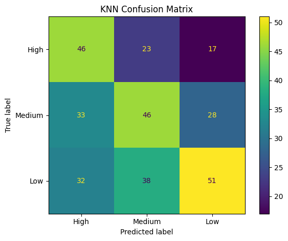

Figure 2: Confusion matrix of KNN model

```python
# Getting predictions on testing set
y_pred_knn = knn.predict(X_test)

# Confusion matrix for KNN model
plot_confusion_matrix(
y_test,
y_pred_knn,
CLASS_NAMES,
"KNN Confusion Matrix"
)
```

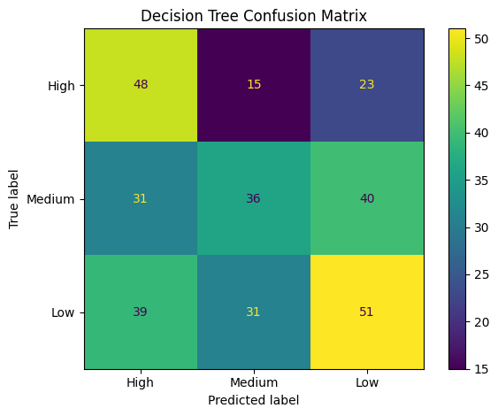

Figure 3: Confusion matrix of DT model

```python
# Getting predictions on testing set
y_pred_dt = dt.predict(X_test)

# Confusion matrix for DT model
dt_plot = plot_confusion_matrix(
y_test,
y_pred_dt,
CLASS_NAMES,
"Decision Tree Confusion Matrix"
)
```

From the KNN confusion matrix (Figure 2), we can observe that the model struggles with `"Low"` instances, as only **42% of 121** `"Low"` instances were correctly classified. On the contrary, the model tends to overpredict `"High"` grades, predicting a total of **111** instances, where only **46** instances were correctly predicted. This shows that the model is **biased towards predicting high grades**.

On the other hand, the DT confusion matrix (Figure 3) displays that the model struggles more with the `"Medium"` class, as only **36** `"Medium"` instances are correctly classified, achieving only **34%** correctly classified as `"Medium"` grades. Like KNN, the DT model overpredicts `High` grades, with only **41%** correctly identified of the **118** predictions made.

These results indicate both models struggle with class overlap, particularly in distinguishing `"Medium"` from `"Low"` and `"High"`. This reflects the weak correlations found in NMI analysis: family-related features do not strongly differentiate academic outcomes.

### Model classification reports

A classification report displays how well the model performs for each class, identifying their strengths and weaknesses of classification (Agarwal et al. 2021).

**Precision** measures the proportion of correct positive predictions out of all positive predictions, **recall** measures the proportion of identified true positives out of actual positives, and the **f1-score** is the harmonic mean of precision and recall (AlShammari 2024).

```python
def get_classification_report(y_pred):
    """
    Creates and cleans a classification report based on the given y predicted set of the model,
    returns a cleaned classification report in a dataframe.
    """

    # Create classification report
    report_dict = sklearn.metrics.classification_report(
        y_test,
        y_pred,
        labels=CLASS_NAMES,
        target_names=CLASS_NAMES,
        output_dict=True
    )

    # Creating dataframe out of classification report dictionary
    report_df = pd.DataFrame(report_dict).transpose()
    report_df = report_df.round(2)

    # Clean dataframe accuracy values
    report_df.loc['accuracy', 'precision'] = None
    report_df.loc['accuracy', 'recall'] = None
    report_df.loc['accuracy', 'support'] = len(y_test)

    return report_df
```

```python
# KNN Classification report
get_classification_report(y_pred_knn)
```

Table 3: Classification report for KNN model

|  | precision | recall | f1-score | support |
| --- | --- | --- | --- | --- |
| High | 0.41 | 0.53 | 0.47 | 86.0 |
| Medium | 0.43 | 0.43 | 0.43 | 107.0 |
| Low | 0.53 | 0.42 | 0.47 | 121.0 |
| accuracy | NaN | NaN | 0.46 | 314.0 |
| macro avg | 0.46 | 0.46 | 0.46 | 314.0 |
| weighted avg | 0.46 | 0.46 | 0.46 | 314.0 |

```python
# DT Classification report
get_classification_report(y_pred_dt)
```

Table 4: Classification report for DT model

|  | precision | recall | f1-score | support |
| --- | --- | --- | --- | --- |
| High | 0.41 | 0.56 | 0.47 | 86.0 |
| Medium | 0.44 | 0.34 | 0.38 | 107.0 |
| Low | 0.45 | 0.42 | 0.43 | 121.0 |
| accuracy | NaN | NaN | 0.43 | 314.0 |
| macro avg | 0.43 | 0.44 | 0.43 | 314.0 |
| weighted avg | 0.43 | 0.43 | 0.43 | 314.0 |

From the classification reports ( Table 3 and Table 4 ), we can observe that both KNN and DT models show mediocre performance in predicting student grades from family factors, with weighted average F1-scores being **0.46** for the KNN model and **0.43** for the DT model. This aligns with the weak correlations found by the NMI analysis, hence supporting the limited predictive power of family features alone.

Both models struggle with classifying the `"Medium"` grade category, as shown by the low recall scores, particularly in the DT model (**0.34** compared to KNN’s **0.43**). This aligns with the weak correlations observed in the NMI analysis, highlighting the limited predictive power of family-related features.

The KNN model demonstrates a more balanced performance, with recall scores ranging from **0.42-0.53**, while the DT shows a wider spread of **0.34-0.56**. This difference reflects on their algorithms:  
- KNN can deal with unclear cases better because its boundaries are more flexible than DTs (Peterson 2009).  
- DT splits data in fixed paths, which can lead to overfitting clearer patterns (`"Low"` and `"High"`) (Ying et al. 2015).

## Model Evaluation and Discussion

### Which model performed better?

Comparing the KNN and DT models using both the confusion matrices (Figure 2 and Figure 3) and classification reports (Table 3 and Table 4), KNN consistently showed slightly stronger performance. Its higher accuracy (**45.5% vs. 43.0%**) and more balanced recall across classes suggest it handles the data distribution more effectively than the DT model (Table 2).

However, concluding that the KNN model performed better than the DT model is not reasonable, as both models performed modestly. This is likely due to the limited amount of training data and basic model configurations. As discussed in the Limitations and Improvements section, **cross validation**, **hyperparameter tuning**, and the use of more advanced models are potential improvements.

### Limitations and Improvements

**Several limitations** impacted the accuracy and reliability of this project:

1. **Limited Feature Set**  
   The analysis used a limited set of familial features. Including more factors, such as parental involvement and other educational support, could improve model training and performance.
2. **Small Sample Size**  
   Insufficient training and testing data limited model training. Expanding the dataset with more students from other schools could improve generalizability and model performance.
3. **Simplified classification**  
   The use of the `"grades_grouped"` categorical variable, though necessary for NMI and the selected models, reduced data granularity. Using alternative correlation measures and regression-based models on continuous grade values would provide more accurate results.
4. **Weak Correlations**  
   Weak correlations identified by NMI (Figure 1) between familial features and academic performance have limited predictive potential. Exploring other association measures like Chi-squared (Zibran 2007) could offer further insights.
5. **Basic Supervised Learning Models**  
   This project utilized basic KNN and DT models with minimal configuration (Zhang 2021). Advanced models (like Random Forests or XGBoost (Fatima et al. 2023)), with **cross-validation** (Berrar et al. 2019) and **hyperparameter tuning** could enhance performance. This could include testing different values of `K` for the KNN model (Batista, Silva, et al. 2009), and adjusting the DT model depth (Saum, Sugiura, and Piantanakulchai 2022). However, these improvements are complex and require additional computational power, so were not implemented in this project.

## Inference

This project investigated the **predictability of student academic performance based on family-related factors**, including parental cohabitation status, education levels, occupations, and family relationship quality, from the Student Performance dataset (Cortez 2008).

**NMI analysis** revealed generally weak associations with all NMI scores being low despite parental education showing the strongest links. This suggests that family background alone does not have a strong relation to academic success, though correlation does not imply causation, which is why all features were used in predictive models. Other factors such as student study time, health, motivation, likely have a greater impact.

**Supervised learning models**, classifying performance into `"Low"`, `"Medium"`, and `"High"`, achieved mediocre accuracy (around 44%), though still better than random chance (33%) (Table 2). This outcome aligns with the weak NMI correlations: family-related features have limited predictive power, and academic outcomes are influenced by a wider range of unexamined factors.

In conclusion, based on this analysis, student academic performance can be predicted to a **limited extent** by the family-related factors, achieving an accuracy of around 40%. While these factors have contributions to the predictions, they are not significant enough to accurately predict student grades, suggesting that student academic outcomes are likely **influenced by a wider array of factors** not considered in this project.

## References

Agarwal, Arushi, Purushottam Sharma, Mohammed Alshehri, Ahmed A Mohamed, and Osama Alfarraj. 2021. “Classification Model for Accuracy and Intrusion Detection Using Machine Learning Approach.” *PeerJ Computer Science* 7: e437. https://peerj.com/articles/cs-437/.

AlShammari, Ahmad Farhan. 2024. “Implementation of Model Evaluation Using Confusion Matrix in Python.” *International Journal of Computer Applications* 975: 8887. https://www.researchgate.net/profile/Ahmad-Alshammari-8/publication/386292671_Implementation_of_Model_Evaluation_using_Confusion_Matrix_in_Python/links/674e3ac9790d154bf9bde0e3/Implementation-of-Model-Evaluation-using-Confusion-Matrix-in-Python.pdf.

Batista, GEAPA, Diego Furtado Silva, et al. 2009. “How k-Nearest Neighbor Parameters Affect Its Performance.” In *Argentine Symposium on Artificial Intelligence*, 1–12. Citeseer. https://citeseerx.ist.psu.edu/document?repid=rep1&type=pdf&doi=b83da505b60e32469152b986cbd6199842403b11.

Berrar, Daniel et al. 2019. “Cross-Validation.” https://dberrar.github.io/papers/Berrar_EBCB_2nd_edition_Cross-validation_preprint.pdf.

Cortez, Paulo. 2008. “Student Performance.” UCI Machine Learning Repository. https://doi.org/10.24432/C5TG7T.

Dahouda, Mwamba Kasongo, and Inwhee Joe. 2021. “A Deep-Learned Embedding Technique for Categorical Features Encoding.” *IEEE Access* 9: 114381–91. https://ieeexplore.ieee.org/abstract/document/9512057.

Fatima, Sana, Ayan Hussain, Sohaib Bin Amir, Syed Haseeb Ahmed, Syed Muhammad Huzaifa Aslam, et al. 2023. “XGBoost and Random Forest Algorithms: An in Depth Analysis.” *Pakistan Journal of Scientific Research* 3 (1): 26–31. https://pdfs.semanticscholar.org/8abb/99db16d6ccc080e3c2a2bb207c9ea20cd5e6.pdf.

Kamat, Prashant V. 2025. “Correlation, Causation and Comparison.” *ACS Energy Letters*. ACS Publications. https://pubs.acs.org/doi/full/10.1021/acsenergylett.5c00631.

Kvalseth, Tarald O. 2017. “On Normalized Mutual Information: Measure Derivations and Properties.” *Entropy* 19 (11): 631. https://www.mdpi.com/1099-4300/19/11/631.

Peterson, Leif E. 2009. “K-Nearest Neighbor.” *Scholarpedia* 4 (2): 1883. http://var.scholarpedia.org/article/K-nearest_neighbor.

Saum, Narith, Satoshi Sugiura, and Mongkut Piantanakulchai. 2022. “Hyperparameter Optimization Using Iterative Decision Tree (Idt).” *IEEE Access* 10: 106812–27. https://ieeexplore.ieee.org/abstract/document/9912397.

Schober, Patrick, Christa Boer, and Lothar A Schwarte. 2018. “Correlation Coefficients: Appropriate Use and Interpretation.” *Anesthesia & Analgesia* 126 (5): 1763–68. https://journals.lww.com/anesthesia-analgesia/fulltext/2018/05000/Correlation_CoefficientsAppropriate_Use_and.50.aspx.

Steuer, R, Juergen Kurths, Carsten Daub, Janko Weise, and J Selbig. 2002. “The Mutual Information: Detecting and Evaluating Dependencies Between Variables.” *Bioinformatics (Oxford, England)* 18 Suppl 2 (February): S231–40. https://doi.org/10.1093/bioinformatics/18.suppl_2.S231.

Ying, LU et al. 2015. “Decision Tree Methods: Applications for Classification and Prediction.” *Shanghai Archives of Psychiatry* 27 (2): 130. https://pmc.ncbi.nlm.nih.gov/articles/PMC4466856/.

Zhang, Shichao. 2021. “Challenges in KNN Classification.” *IEEE Transactions on Knowledge and Data Engineering* 34 (10): 4663–75. https://ieeexplore.ieee.org/abstract/document/9314060.

Zibran, Minhaz Fahim. 2007. “Chi-Squared Test of Independence.” *Department of Computer Science, University of Calgary, Alberta, Canada* 1 (1): 1–7. https://cspages.ucalgary.ca/~saul/wiki/uploads/CPSC681/topic-fahim-CHI-Square.pdf.